# IRBs & Data Sharing

2017-07-30 09:26:36

## IRBs & Data Sharing

**2017-07-30 3:30-4:15 pm**

See http://osf.io/9d5hr/

## Acknowledgements

[figure not shown]

## Vision

- Make data from psychological research as widely available as possible
  - Increase reuse potential
  - Reduce bias
  - Make published analyses as transparent as possible
- Avoid harming research participants

## Roadmap

- Ethical challenges in sharing data
- Sharing de-identified data
- Sharing identifiable data

## Ethical challenges in sharing data

## [Belmont principles](https://www.hhs.gov/ohrp/regulations-and-policy/belmont-report/index.html)

- **Beneficence**
  - Data sharing increases value (good)
  - Data sharing may pose risk of loss of privacy & confidentiality (bad)
- **Autonomy**
  - Data sharing may pose risk of unintended use of data
  - Participants should participate in decisionmaking
- **Justice**
  - Benefits (and costs) of research participation should be equitable

## Meeting the challenges

- Tension b/w protecting participants & advancing discovery
- Tension b/w requirements/expectations/desires to share and practical, regulatory/legal, ethical constraints

## What data are you collecting?

- Personally identifying or sensitive data?
- What risks does data sharing pose?
- How should data be protected?

## Who will (& should) have access?

- Public
- Community of authorized individuals (researchers)
- Individuals selected by data owner or repository

## What have participants been told, approved, understood?

- What data collected, what will be shared
- Who will have access
- Where stored, how accessed
- Purposes of use, types of questions

## Are your data subject to statutory, regulatory, or contractual restrictions?

- Students ([FERPA](https://www2.ed.gov/policy/gen/guid/fpco/ferpa/index.html))
- Health ([HIPAA](https://www.hhs.gov/hipaa/for-professionals/security/laws-regulations/index.html))
- From Federal agencies ([Title 13](https://www.census.gov/history/www/reference/privacy_confidentiality/title_13_us_code.html), [Title 26](https://www.law.cornell.edu/uscode/text/26))
- Proprietary data

## Sharing de-identified data

## What is personally identifying information (PII)?

- [PII definitions](https://en.wikipedia.org/wiki/Personally_identifiable_information) vary by use case, context
- Likelihood of identification depends on uniqueness in target and reference populations
- Health Insurance Portability and Accountability Act (HIPAA) identifiers

## HIPAA identifiers

- Name
- Address (all geographic subdivisions smaller than state, including street address, city, county, and zip code)
- All elements (except years) of **dates** related to an individual (including birthdate, admission date, discharge date, date of death, and exact age if over 89)
- Telephone
- Fax numbers
- Email address
- Social Security Number
- Medical record number
- Health plan beneficiary number
- Account number
- Certificate or license number
- Any vehicle or other device serial number
- Web URL
- **Internet Protocol (IP) Address**
- Finger or voice print
- Photographic image - not limited to images of the face
- Any other characteristic that could uniquely identify the individual

## Other potentially identifiable information

- Structural MRI
  - Emerging standard: deface
- Genetic profiles

## Examples of possibly sensitive data

- Health-related information
  - Medical history
  - Medical risk factors including genetic data
- Information about other potentially stigmatizing characteristics (situation-dependent)
  - Religious/philosophical convictions
  - Sexual identity and preferences
  - Political affiliation, trade union membership
  - Ethnicity, nationality, citizenship status

## Weighing benefits (of sharing) vs. risks

- How useful are data?
- How sensitive are data?
- How likely is it that reidentification could be achieved, and by whom?

## Risk scenarios

- Reidentification by participants themselves
  - Can be harmful e.g. if dataset contains uncommunicated health risk information
- Reidentification by insider
- Reidentification by targeted search (nemesis scenario)
- Reidentification by mass matching (dystopian AI scenario)

## Ways to mitigate risk

- Aggregate or censor sensitive variables
- Aggregate or censor secondary identifying variables
- Perturb or add noise to variables
- Review data for disclosure risk
- Stepped or restricted access
  - Data enclaves (e.g., Census data)
  - Virtual data enclaves

## Example language for consent forms

- [ICPSR](https://www.icpsr.umich.edu/icpsrweb/content/datamanagement/confidentiality/conf-language.html)
- [Open Brain consent](https://open-brain-consent.readthedocs.io/en/latest/#)
- [Draft language from Penn State IRB](https://osf.io/9d5hr/wiki/home/)
- [Databrary sharing release template](https://www.databrary.org/access/policies/release-template.html)

## Case study: [OpenNeuro.org](http://openneuro.org)

[figure not shown]

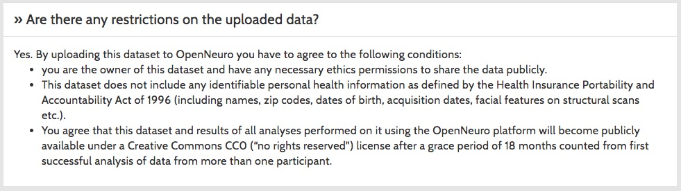

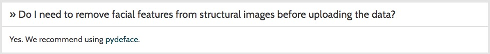

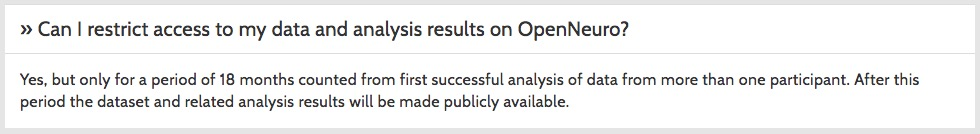

## Sharing *identifiable* data

## [Canadian Policy](http://www.pre.ethics.gc.ca/eng/policy-politique/initiatives/tcps2-eptc2/chapter5-chapitre5/#toc05-1e)

- Ethics board review **not required** for research that relies exclusively on secondary use of *anonymous* information
- [*"**Secondary data** refers to data that was collected by someone other than the user. Common sources of secondary data for social science include censuses, information collected by government departments, organisational records and data that was originally collected for other research purposes."*](https://en.wikipedia.org/wiki/Secondary_data)
- Researchers must obtain consent for secondary use of *identifiable* data **unless**
  - identifiable information is essential to the research
  - use of identifiable information without consent is unlikely to adversely affect participants
  - researchers take appropriate measures to protect privacy of individuals and safeguard identifiable information
- Researchers must obtain consent for secondary use of *identifiable* data **unless**
  - researchers comply with any known preferences previously expressed by individuals about any use of their information
  - it is impossible or impracticable to seek consent
  - researchers have obtained any other necessary permission for secondary use of information for research purposes.

## Case studies in sharing identifiable data

- Databrary.org
- [Open Humans](https://www.openhumans.org/)

## [Databrary.org](http://databrary.org)

[figure not shown]

## [Databrary.org](http://databrary.org)

- Specializes in storing, sharing video
- Video captures behavior more fully than other methods, but is *identifiable*
- Policy framework for sharing identifiable data
  - **Permission to share** -> builds on informed consent
  - **Restricted access** for (institutionally) authorized researchers

[figure not shown]

## Seeking [permission to share](https://www.databrary.org/access/guide/investigators/release.html)

[video not shown]

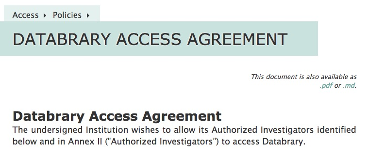

## Lessons learned

- Research consent ≠ permission to share
  - Seek permission to share *after* data collection.
- "Cloud" storage vs. institutionally housed
- Comfort with data sharing varies among IRBs
- Laws differ among countries

## Open Humans

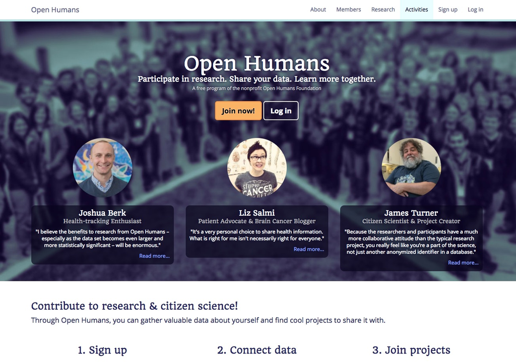

## Public sharing of identifiable data

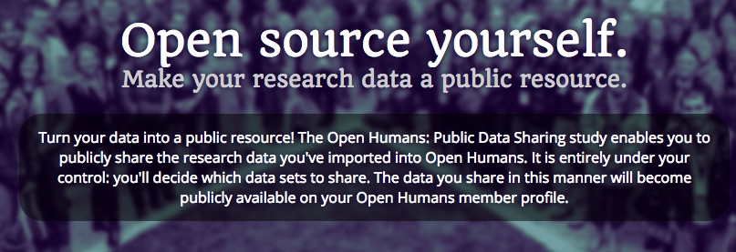

## Risks of public sharing

- Identity theft
- Embarrassment
- Discrimination
- Data may later become sensitive
- Can withdraw, but can't "unshare"

Open Humans: Public Data Sharing Consent

## Specific risks for sharing these data types

- Demographic data
- Genetic data
- Location data

Open Humans: Public Data Sharing Consent

## Benefits of public sharing

- Public data as a public resource
- Serves diverse individuals not part of standard research groups
- Participants can advance their own understanding

Open Humans: Public Data Sharing Consent

## Recommendations

## **Prepare for sharing**

- Get IRB/ethics board approval
- Get participant approval (even if planning to anonymize)

## **Alert participants**

- **Where** data will be stored
  - e.g. in "cloud" servers (e.g., SurveyMonkey, Qualtrics, Databrary, OpenNeuro, OSF, etc.)
  - Be explicit, but not specific
- **Who** will have access
  - Public/anyone
  - Researchers
- And for **how long**
  - indefinitely
  - stopping sharing possible, unsharing not-so
- **Why**:
  - Give motivation for recording sensitive variables (beneficence)
- Consult data repository experts (e.g., [ICPSR](https://www.icpsr.umich.edu/icpsrweb/), [Dataverse](http://dataverse.org), [Databrary](http://databrary.org))
- **Avoid** making promises you cannot keep:
  - *"no one except the researchers in the project will ever see the data"*
- **Avoid** data destruction clauses:
  - *"Your data will be stored for X years then destroyed."*
  - **NOT REQUIRED by U.S. or Canadian law**
- Avoid describing overly specific use cases for data:
  - *"Your data will be used to study the relationship between X and Y."*

## **Share as openly as practicable**

- Consider approved, authorized, [trusted](http://www.oclc.org/research/activities/trustedrep.html) data repositories for sensitive data
- **Share as much individual-level, item-specific data as practicable**
  - Finest grain data == highest value for reuse, new discovery

## Discussion

## How anonymous is 'anonymous' data?

- "Big Data’s End Run around Anonymity and Consent" [Barocas & Nissenbaum 2014](http://dx.doi.org/10.1017/CBO9781107590205.004)

[figure not shown]

[figure not shown]

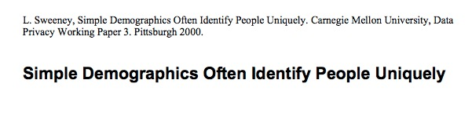

## Other issues

- Self-reported vs. medical records
- Sponsor requirements (or constraints) vs. open sharing
- Do IRBs overstep regulatory boundaries when considering risks and benefits outside an approved study [(Burnam, 2014)](http://osc.centerforopenscience.org/2014/02/05/open-data-and-IRBs)?
- Policies for restricting access but promoting openness
- Who owns data?

## [DataTags](https://datatags.org/) initiative

- From [Dataverse](http://dataverse.org) @ Harvard
- Checklist/workflow for 'tagging' data based on risk

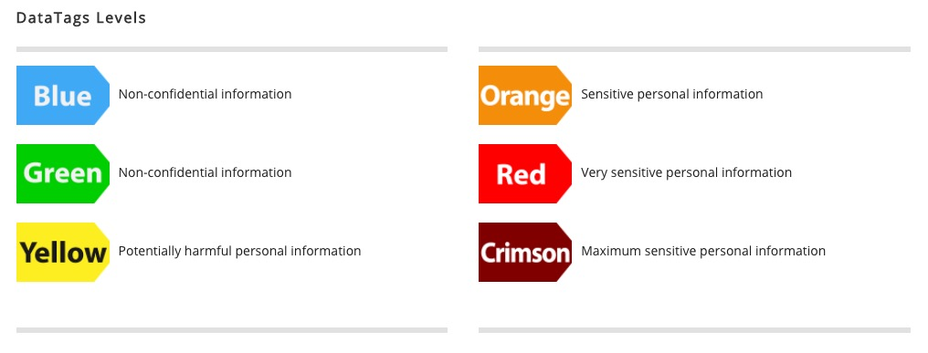